# Assignment 1.1

Marcos Cunchillos Just

2026-10-02

## Exercise 1

Using the **anorexia** dataset from the **MASS** package, which contains weight-change data for young patients with anorexia, display the data types it contains and check whether there are any `NA` or `NULL` values.

```r
# Data type of each column
sapply(anorexia, class)
```

```
##     Treat     Prewt    Postwt
##  "factor" "numeric" "numeric"
```

```r
# Any missing values in the whole data frame?
any(is.na(anorexia))
```

```
## [1] FALSE
```

```r
# Is any column NULL?
sapply(anorexia, is.null)
```

```
##  Treat  Prewt Postwt
##  FALSE  FALSE  FALSE
```

For the variable `Treat`, recode the values “CBT”, “Cont” and “FT” as “Cogn Beh Tr”, “Contr” and “Fam Tr”, respectively.

```r
# Work on a copy so the original dataset stays untouched
anorexia_clean <- anorexia

# Assign new labels by position
levels(anorexia_clean$Treat) <- c("Cogn Beh Tr", "Contr", "Fam Tr")
```

## Exercise 2

**a)** Export the **biopsy** data from the **MASS** package to a `.csv` file.

```r
# Create the output folder
dir.create("data", showWarnings = FALSE)

# Export the biopsy dataset to a CSV file
write.csv(biopsy, file = file.path("data", "biopsy.csv"))
```

**b)** Generate a summary of the variable `age` from the **Melanoma** dataset and save the output shown in the console to a `.doc` document.

```r
age_summary <- summary(Melanoma$age)
age_summary
```

```
##    Min. 1st Qu.  Median    Mean 3rd Qu.    Max.
##    4.00   42.00   54.00   52.46   65.00   95.00
```

```r
# Capture the console output and write it to a file that Word can open
writeLines(
  capture.output(print(age_summary)),
  con = "summary_age.doc"
)
```

**c)** Find a data frame in a biomedical data repository, download a dataset as a `.csv` file and import it into an R Markdown document using code or the RStudio import menu.

```r
# Breast Cancer Wisconsin (Diagnostic) dataset, UCI Machine Learning Repository
url <- "https://archive.ics.uci.edu/ml/machine-learning-databases/breast-cancer-wisconsin/wdbc.data"
datos <- read_csv(url, col_names = FALSE)
```

## Exercise 3

The following example shows how to use different operators on the **birthwt** dataset, as well as some functions that provide more information about its variables.

**a)** What is the maximum age of the mothers in the dataset?

```r
max(birthwt$age)
```

```
## [1] 45
```

**b)** What is the minimum age of the mothers in the dataset?

```r
min(birthwt$age)
```

```
## [1] 14
```

**c)** What is the age range of the mothers?

```r
# Range = maximum - minimum
age_range <- max(birthwt$age) - min(birthwt$age)
age_range
```

```
## [1] 31
```

**d)** Did the mother of the lowest-birth-weight newborn smoke?

```r
# Smoking status of the mother whose newborn had the minimum birth weight
birthwt$smoke[birthwt$bwt == min(birthwt$bwt)]
```

```
## [1] 1
```

**e)** How much did the newborn whose mother had the maximum age weigh?

```r
# Birth weight of the newborn(s) whose mother had the maximum age
birthwt$bwt[birthwt$age == max(birthwt$age)]
```

```
## [1] 4990
```

**f)** List the birth weights of the newborns whose mothers made fewer than two physician visits during the first trimester.

```r
subset(birthwt, ftv < 2, select = bwt)
```

|  | bwt |
| --- | --- |
| 85 | 2523 |
| 87 | 2557 |
| 89 | 2600 |
| 91 | 2622 |
| 92 | 2637 |
| 93 | 2637 |
| 94 | 2663 |
| 95 | 2665 |
| 96 | 2722 |
| 97 | 2733 |

[output cut: 137 more lines]

## Exercise 4

Using the **anorexia** dataset from the previous sections, create a matrix whose columns are the values of `Prewt` and `Postwt`, with each row holding the corresponding values for each observation.

```r
anorexia_matrix <- matrix(c(anorexia$Prewt, anorexia$Postwt), ncol = 2)
```

## Exercise 5

Copy the following code into your console to generate a data frame with twenty-five records and six variables, and answer the questions below.

```r
Identificador <- c(
  "I1", "I2", "I3", "I4", "I5", "I6", "I7", "I8", "I9", "I10", "I11", "I12",
  "I13", "I14", "I15", "I16", "I17", "I18", "I19", "I20", "I21", "I22", "I23",
  "I24", "I25"
)

Edad <- c(
  23, 24, 21, 22, 23, 25, 26, 24, 21, 22, 23, 25, 26,
  24, 22, 21, 25, 26, 24, 21, 25, 27, 26, 22, 29
)

# Sex: 1 = female, 2 = male
Sexo <- c(
  1, 2, 1, 1, 1, 2, 2, 2, 1, 2, 1, 2, 2,
  2, 1, 1, 1, 2, 2, 2, 1, 2, 1, 1, 2
)

Peso <- c(
  76.5, 81.2, 79.3, 59.5, 67.3, 78.6, 67.9, 100.2, 97.8, 56.4, 65.4, 67.5,
  87.4, 99.7, 87.6, 93.4, 65.4, 73.7, 85.1, 61.2, 54.8, 103.4, 65.8, 71.7,
  85.0
)

# Height in cm
Alt <- c(
  165, 154, 178, 165, 164, 175, 182, 165, 178, 165, 158, 183, 184,
  164, 189, 167, 182, 179, 165, 158, 183, 184, 189, 166, 175
)

# Smoker: "SÍ" = yes, "NO" = no
Fuma <- c(
  "SÍ", "NO", "SÍ", "SÍ", "NO", "NO", "NO", "SÍ", "SÍ", "SÍ", "NO", "NO", "SÍ",
  "SÍ", "SÍ", "SÍ", "NO", "NO", "SÍ", "SÍ", "SÍ", "NO", "SÍ", "NO", "SÍ"
)

Trat_Pulmon <- data.frame(Identificador, Edad, Sexo, Peso, Alt, Fuma)
Trat_Pulmon
```

| Identificador | Edad | Sexo | Peso | Alt | Fuma |
| --- | --- | --- | --- | --- | --- |
| I1 | 23 | 1 | 76.5 | 165 | SÍ |
| I2 | 24 | 2 | 81.2 | 154 | NO |
| I3 | 21 | 1 | 79.3 | 178 | SÍ |
| I4 | 22 | 1 | 59.5 | 165 | SÍ |
| I5 | 23 | 1 | 67.3 | 164 | NO |
| I6 | 25 | 2 | 78.6 | 175 | NO |
| I7 | 26 | 2 | 67.9 | 182 | NO |
| I8 | 24 | 2 | 100.2 | 165 | SÍ |
| I9 | 21 | 1 | 97.8 | 178 | SÍ |
| I10 | 22 | 2 | 56.4 | 165 | SÍ |

[output cut: 15 more lines]

**a)** Select the records with age > 22.

```r
subset(Trat_Pulmon, Edad > 22)
```

|  | Identificador | Edad | Sexo | Peso | Alt | Fuma |
| --- | --- | --- | --- | --- | --- | --- |
| 1 | I1 | 23 | 1 | 76.5 | 165 | SÍ |
| 2 | I2 | 24 | 2 | 81.2 | 154 | NO |
| 5 | I5 | 23 | 1 | 67.3 | 164 | NO |
| 6 | I6 | 25 | 2 | 78.6 | 175 | NO |
| 7 | I7 | 26 | 2 | 67.9 | 182 | NO |
| 8 | I8 | 24 | 2 | 100.2 | 165 | SÍ |
| 11 | I11 | 23 | 1 | 65.4 | 158 | NO |
| 12 | I12 | 25 | 2 | 67.5 | 183 | NO |
| 13 | I13 | 26 | 2 | 87.4 | 184 | SÍ |
| 14 | I14 | 24 | 2 | 99.7 | 164 | SÍ |

[output cut: 7 more lines]

**b)** Select element 3 of column 4 of the dataset (counting the identifier column).

```r
Trat_Pulmon[3, 4]
```

```
## [1] 79.3
```

**c)** Use `subset()` to select all rows with age under 27 years, excluding the `Alt` column.

```r
subset(Trat_Pulmon, Edad < 27, select = -c(Alt))
```

|  | Identificador | Edad | Sexo | Peso | Fuma |
| --- | --- | --- | --- | --- | --- |
| 1 | I1 | 23 | 1 | 76.5 | SÍ |
| 2 | I2 | 24 | 2 | 81.2 | NO |
| 3 | I3 | 21 | 1 | 79.3 | SÍ |
| 4 | I4 | 22 | 1 | 59.5 | SÍ |
| 5 | I5 | 23 | 1 | 67.3 | NO |
| 6 | I6 | 25 | 2 | 78.6 | NO |
| 7 | I7 | 26 | 2 | 67.9 | NO |
| 8 | I8 | 24 | 2 | 100.2 | SÍ |
| 9 | I9 | 21 | 1 | 97.8 | SÍ |
| 10 | I10 | 22 | 2 | 56.4 | SÍ |

[output cut: 13 more lines]

## Exercise 6

Load the **ChickWeight** dataset, which contains information on the weight of 578 chicks in grams (`weight`), the time since the measurement at birth (`Time`), an identifier variable for each chick (`Chick`) based on weight range, and a factor variable with the experimental diet each chick received (`Diet`).

**a)** Load the **ChickWeight** dataset from the **datasets** package into your working environment.

```r
data(ChickWeight)
```

**b)** Create a scatter plot of the variable `weight`.

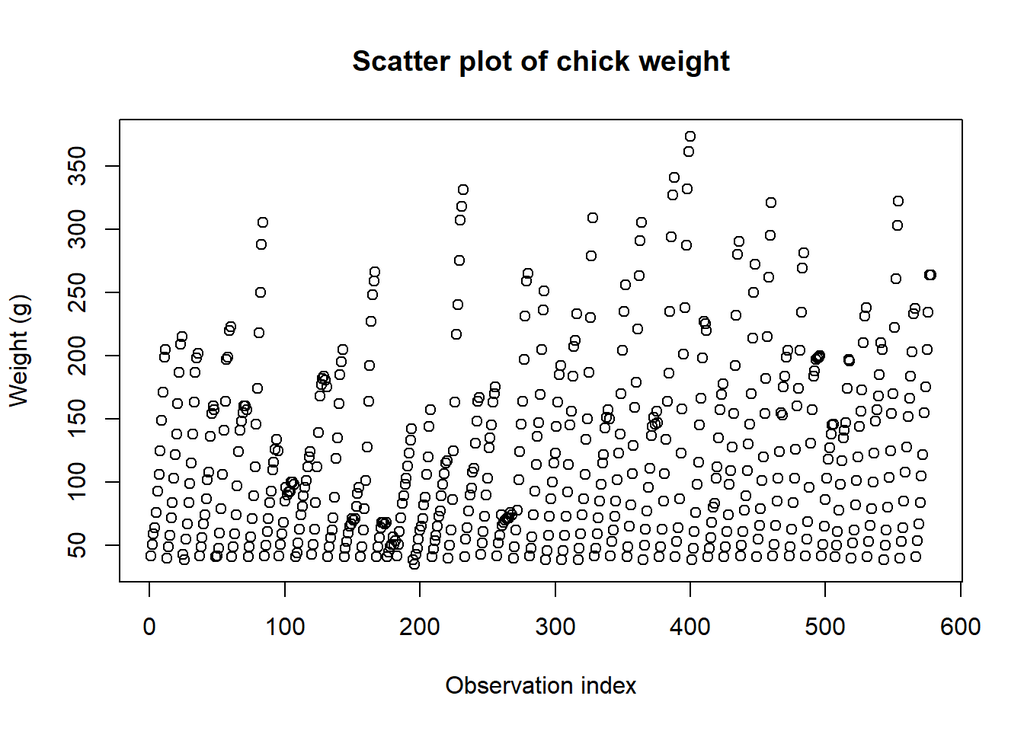

```r
plot(
  ChickWeight$weight,
  xlab = "Observation index",
  ylab = "Weight (g)",
  main = "Scatter plot of chick weight"
)
```

**c)** Create a boxplot of the variable `Time`.

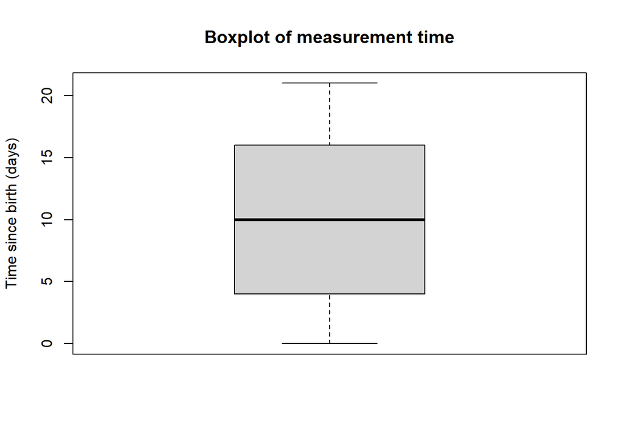

```r
boxplot(
  ChickWeight$Time,
  ylab = "Time since birth (days)",
  main = "Boxplot of measurement time"
)
```

## Exercise 7

Using the **anorexia** dataset from the **MASS** package, create another data frame called `anorexia_treat_df` consisting of `Treat` and a new vector computed from the difference `Postwt - Prewt`. The result is a data frame containing the treatment type and the weight gained or lost after the treatment.

```r
# Weight change after treatment (Postwt - Prewt)
after_treatment <- anorexia$Postwt - anorexia$Prewt

anorexia_treat_df <- data.frame(anorexia$Treat, after_treatment)
```

Select the individuals who gained weight after treatment and create a new dataset called `anorexia_treat_C_df` containing only those who followed the “Cont” treatment and gained weight.

```r
anorexia_treat_C_df <- anorexia_treat_df |>
  filter(anorexia.Treat == "Cont", after_treatment > 0)
```

## Exercise 8

Solve the following sections.

**a)** Create a fictitious dataset in R. It must contain thirty observations (fifteen men and fifteen women) for six variables (ID, Age, Gender, Treatment, Weight, Height).

```r
# Fix the seed so the simulated data are identical on every knit
set.seed(123)

Id <- 1:30
Age <- round(rnorm(30, mean = 65, sd = 8))
Gender <- c(rep(1, 15), rep(2, 15))
Treat <- c(rep("A", 10), rep("B", 10), rep("C", 10))
Wt <- round(rnorm(30, mean = 65, sd = 7))
Ht <- round(rnorm(30, mean = 175, sd = 10))

Health_Data <- data.frame(Id, Age, Gender, Treat, Wt, Ht)
```

**b)** Explore your dataset and its variables.

```r
summary(Health_Data)
```

```
##        Id             Age            Gender          Treat          Wt
##  Min.   : 1.00   Min.   :49.00   Min.   :1.0   Length   :30   Min.   :54.00
##  1st Qu.: 8.25   1st Qu.:60.00   1st Qu.:1.0   N.unique : 3   1st Qu.:63.00
##  Median :15.50   Median :64.50   Median :1.5   N.blank  : 0   Median :65.50
##  Mean   :15.50   Mean   :64.67   Mean   :1.5   Min.nchar: 1   Mean   :66.27
##  3rd Qu.:22.75   3rd Qu.:69.00   3rd Qu.:2.0   Max.nchar: 1   3rd Qu.:70.00
##  Max.   :30.00   Max.   :79.00   Max.   :2.0                  Max.   :80.00
##        Ht
##  Min.   :152.0
##  1st Qu.:170.2
##  Median :175.5
##  Mean   :175.2
##  3rd Qu.:179.0
##  Max.   :196.0
```

**c)** Create a new variable from one of the existing ones. For example, compute the BMI (`BMI = weight (kg) / height (m)^2`) and add it to the dataset.

```r
# Height is stored in cm, so divide by 100 to get metres
BMI <- Health_Data$Wt / (Health_Data$Ht / 100)**2
Health_Data_2 <- cbind(Health_Data, BMI)
```

**d)** Create two separate data frames for men and women with two different names: `Df_Men` and `Df_Women`.

```r
Df_Men <- Health_Data |>
  filter(Gender == 1)

Df_Women <- Health_Data |>
  filter(Gender == 2)
```

**e)** Recombine the two previous data frames and recreate the first one using `rbind()`.

```r
Health_Data_3 <- rbind(Df_Men, Df_Women)
```